# Hospital

The data for this project comes from the [Hospital Compare Website](http://hospitalcompare.hhs.gov) run by the US Department of Health and Human Services. The purpose of the website is to provide data and information about the quality of care at over 4,000 Medicare-certified hospitals in the US. This dataset essentially covers all major US hospitals. This dataset is used for a variety of purposes, including determining whether hopsitals should be fined for not providing high quality care to patients([see](http://goo.gl/jAXFX) for some background on this particular topic).

The Hospital Compare website contains a lot of data and we will only look at a small subset for this project. We have three files:

```
* outcome-of-care-measures.csv: Contains information about 30-day mortality and readmission rates for heart attacks, heart failure, and pneumonia for over 4,000 hospitals.
* hospital-data.csv: Contains information about each hospital.
* Hospital_Revised_Flatfiles.pdf: Descriptions of the variables in each file (i.e. the code book).
```

A description of the variables in each of the files is in the included PDF file named Hospital_Revised_Flatfiles.pdf. This document contains information about many other files that are not included in this project. You will want to focus on the variables for Number 19 (“Outcome of Care Measures.csv”) and Number 11 (“Hospital Data.csv”).

# Plotting the 30-day mortality rates for heart attack

```r
outcome <- read.csv("data/hospital/outcome-of-care-measures.csv", colClasses="character")
head(outcome)
```

|  | Provider.Number | Hospital.Name | Address.1 | Address.2 | Address.3 | City | State | ZIP.Code | County.Name | Phone.Number | Hospital.30.Day.Death..Mortality..Rates.from.Heart.Attack | Comparison.to.U.S..Rate...Hospital.30.Day.Death..Mortality..Rates.from.Heart.Attack | Lower.Mortality.Estimate...Hospital.30.Day.Death..Mortality..Rates.from.Heart.Attack | Upper.Mortality.Estimate...Hospital.30.Day.Death..Mortality..Rates.from.Heart.Attack | Number.of.Patients...Hospital.30.Day.Death..Mortality..Rates.from.Heart.Attack | Footnote...Hospital.30.Day.Death..Mortality..Rates.from.Heart.Attack | Hospital.30.Day.Death..Mortality..Rates.from.Heart.Failure | Comparison.to.U.S..Rate...Hospital.30.Day.Death..Mortality..Rates.from.Heart.Failure | Lower.Mortality.Estimate...Hospital.30.Day.Death..Mortality..Rates.from.Heart.Failure | Upper.Mortality.Estimate...Hospital.30.Day.Death..Mortality..Rates.from.Heart.Failure | Number.of.Patients...Hospital.30.Day.Death..Mortality..Rates.from.Heart.Failure | Footnote...Hospital.30.Day.Death..Mortality..Rates.from.Heart.Failure | Hospital.30.Day.Death..Mortality..Rates.from.Pneumonia | Comparison.to.U.S..Rate...Hospital.30.Day.Death..Mortality..Rates.from.Pneumonia | Lower.Mortality.Estimate...Hospital.30.Day.Death..Mortality..Rates.from.Pneumonia | Upper.Mortality.Estimate...Hospital.30.Day.Death..Mortality..Rates.from.Pneumonia | Number.of.Patients...Hospital.30.Day.Death..Mortality..Rates.from.Pneumonia | Footnote...Hospital.30.Day.Death..Mortality..Rates.from.Pneumonia | Hospital.30.Day.Readmission.Rates.from.Heart.Attack | … |
| --- | --- | --- | --- | --- | --- | --- | --- | --- | --- | --- | --- | --- | --- | --- | --- | --- | --- | --- | --- | --- | --- | --- | --- | --- | --- | --- | --- | --- | --- | --- |
| 1 | 010001 | SOUTHEAST ALABAMA MEDICAL CENTER | 1108 ROSS CLARK CIRCLE |  |  | DOTHAN | AL | 36301 | HOUSTON | 3347938701 | 14.3 | No Different than U.S. National Rate | 12.1 | 17.0 | 666 |  | 11.4 | No Different than U.S. National Rate | 9.5 | 13.7 | 741 |  | 10.9 | No Different than U.S. National Rate | 8.6 | 13.7 | 371 |  | 19.0 | … |
| 2 | 010005 | MARSHALL MEDICAL CENTER SOUTH | 2505 U S HIGHWAY 431 NORTH |  |  | BOAZ | AL | 35957 | MARSHALL | 2565938310 | 18.5 | No Different than U.S. National Rate | 14.7 | 23.0 | 44 |  | 15.2 | Worse than U.S. National Rate | 12.2 | 18.8 | 234 |  | 13.9 | No Different than U.S. National Rate | 11.3 | 17.0 | 372 |  | Not Available | … |
| 3 | 010006 | ELIZA COFFEE MEMORIAL HOSPITAL | 205 MARENGO STREET |  |  | FLORENCE | AL | 35631 | LAUDERDALE | 2567688400 | 18.1 | No Different than U.S. National Rate | 14.8 | 21.8 | 329 |  | 11.3 | No Different than U.S. National Rate | 9.1 | 13.9 | 523 |  | 13.4 | No Different than U.S. National Rate | 11.2 | 15.8 | 836 |  | 17.8 | … |
| 4 | 010007 | MIZELL MEMORIAL HOSPITAL | 702 N MAIN ST |  |  | OPP | AL | 36467 | COVINGTON | 3344933541 | Not Available | Number of Cases Too Small | Not Available | Not Available | 14 | number of cases is too small (fewer than 25) to reliably tell how well the hospital is performing | 13.6 | No Different than U.S. National Rate | 10.0 | 18.2 | 113 |  | 14.9 | No Different than U.S. National Rate | 11.6 | 19.0 | 239 |  | Not Available | … |
| 5 | 010008 | CRENSHAW COMMUNITY HOSPITAL | 101 HOSPITAL CIRCLE |  |  | LUVERNE | AL | 36049 | CRENSHAW | 3343353374 | Not Available | Number of Cases Too Small | Not Available | Not Available | 9 | number of cases is too small (fewer than 25) to reliably tell how well the hospital is performing | 13.8 | No Different than U.S. National Rate | 9.9 | 18.7 | 53 |  | 15.8 | No Different than U.S. National Rate | 11.4 | 21.5 | 61 |  | Not Available | … |
| 6 | 010010 | MARSHALL MEDICAL CENTER NORTH | 8000 ALABAMA HIGHWAY 69 |  |  | GUNTERSVILLE | AL | 35976 | MARSHALL | 2565718000 | Not Available | Number of Cases Too Small | Not Available | Not Available | 22 | number of cases is too small (fewer than 25) to reliably tell how well the hospital is performing | 12.5 | No Different than U.S. National Rate | 9.9 | 15.6 | 163 |  | 8.7 | Better than U.S. National Rate | 6.8 | 11.0 | 315 |  | Not Available | … |

There are many columns in this dataset. We can see how many by typing ncol(outcome)

```r
ncol(outcome)
```

```
[1] 46
```

To make a simple histogram of the 30-day death rates from heart attack (column 11 in the outcome dataset), we need to run:-

```r
outcome[,11] <- as.numeric(outcome[,11])
```

```
NAs introduced by coercion
```

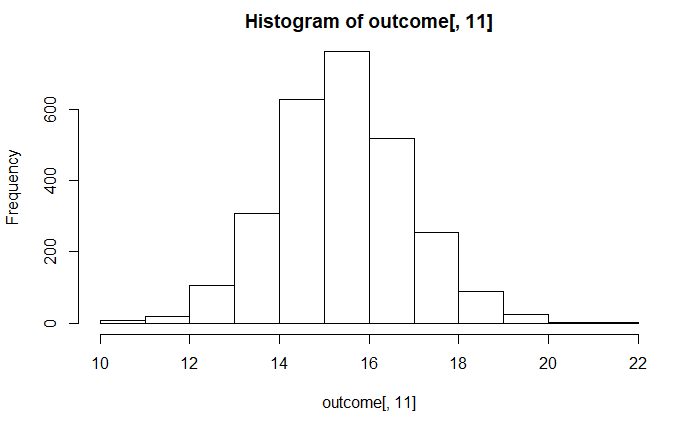

```r
# We may get a warning about NAs being introduce, but that's OK
hist(outcome[, 11])
```

Because we originally read the data in as character (by specifying colClasses = “character”, we need to coerce the column to be numeric).

# Finding the best hospital in a state

**Handling ties.** If there is a tie for the best hospital for a given outcome, then the hospital names should be sorted in alphabetical order and the first hospital in that set should be chosen (i.e. if hospitals “b”, “c”, and “f” are tied for the best, then hospital “b” should be returned).

```r
library(dplyr)
library(tidyr)
library(magrittr)
# Finding the best hospital in a state
best <- function(mystate, outcome) {
    # read the outcome data
    data <- read.csv("data/hospital/outcome-of-care-measures.csv", colClasses="character")

    # first change the needed columns to numeric.
    # To supress warnings I'm introducing supressWarnings()
    data[, 11] <- suppressWarnings(as.numeric(data[, 11]))
    data[, 17] <- suppressWarnings(as.numeric(data[, 17]))
    data[, 23] <- suppressWarnings(as.numeric(data[, 23]))

    # remove unwanted columns
    data <- data %>%
        select(Hospital.Name, City, State,
               Hospital.30.Day.Death..Mortality..Rates.from.Heart.Attack,
               Hospital.30.Day.Death..Mortality..Rates.from.Heart.Failure,
               Hospital.30.Day.Death..Mortality..Rates.from.Pneumonia)

    # Now shorten the column names
    colnames(data) <- c("hospital", "city", "state", "heart attack", "heart failure", "pneumonia")

    # Check that state and outcome are valid
    # First check validity of the state
    if(mystate %in% data$state) {
        TRUE
    } else {
        stop("invalid state")
    }

    # Now check validity of outcome
    # put column names in a list
    col_list <- as.list(colnames(data))
    outcome <- tolower(outcome)
    if(outcome %in% col_list) {
        TRUE
    } else {
        stop("invalid outcome")
    }

    # Return hospital name in that state with lowest 30-day death rate
    # first filter only the state required and select only the outcome column
    data <- data %>%
        select(hospital, city, state, outcome) %>%
        filter(state == mystate, data[,4] != "NA") # since we now have only 4 columns,
    # hospital, city, state and outcome, the outcome column is 4 so I had to  use this
    # way to drop the rows with NAs. Other ways were not working.
    # now order the data.
    data_1 <- data[order(data[,4], data[,1]),]

    return(data_1[1,1])
}
best("TX", "heart attack")
```

```
[1] "CYPRESS FAIRBANKS MEDICAL CENTER"
```

```r
best("TX", "heart failure")
```

```
[1] "FORT DUNCAN MEDICAL CENTER"
```

```r
best("MD", "heart attack")
```

```
[1] "JOHNS HOPKINS HOSPITAL, THE"
```

```r
best("MD", "pneumonia")
```

```
[1] "GREATER BALTIMORE MEDICAL CENTER"
```

```r
best("BB", "heart attack")
```

```
Error in best("BB", "heart attack") : invalid state
```

```r
best("NY", "hert attack")
```

```
Error in best("NY", "hert attack") : invalid outcome
```

# Ranking hospitals by outcome in a state

Let’s write a function called **rankhospital** that takes three arguments: the 2-character abbreviated name of a state (state), an outcome (outcome), and the ranking of a hospital in that state for that state for that outcome (num). The function reads the outcome-of-care-measures.csv file and returns a character vector with the name of the hospital that has the ranking specified by the num argument. For example, the call *rankhospital(“MD”, “heart failure”, 5)* would return a character vector containing the name of the hospital with the 5th lowest 30-day death rate for heart failure. The num argument can take values “best”, “worst”, or an integer indicating the ranking (smaller numbers are better). If the number given by num is larger than the number of hospitals in that state, then the function should return NA. Hospitals that do not have data on a particular outcome should be excluded from the set of hospitals when deciding the rankings.

**Handling ties.** It may occur that multiple hospitals have the same 30-day mortality rate for a given cause of death. In those cases ties should be broken by using the hospital name.

```r
rankhospital <- function(mystate, outcome, rank="best") {
    ## Read outcome data
    data <- read.csv("data/hospital/outcome-of-care-measures.csv", colClasses = "character")
    ## first change the needed columns to numeric. To suppress warnings I'm
    # introducing suppressWarnings()
    data[, 11] <- suppressWarnings(as.numeric(data[, 11]))
    data[, 17] <- suppressWarnings(as.numeric(data[, 17]))
    data[, 23] <- suppressWarnings(as.numeric(data[, 23]))

    ## remove unwanted columns
    data <- data %>%
        select(Hospital.Name, City, State,
               Hospital.30.Day.Death..Mortality..Rates.from.Heart.Attack,
               Hospital.30.Day.Death..Mortality..Rates.from.Heart.Failure,
               Hospital.30.Day.Death..Mortality..Rates.from.Pneumonia)
    # Now shorten the column names
    colnames(data) <- c("hospital", "city", "state", "heart attack", "heart failure", "pneumonia")

    ## Check that state and outcome are valid
    # First check validity of state
    if(mystate %in% data$state) {
        TRUE
    } else {
        stop("invalid state")
    }

    # Now check validity of outcome
    # put column names in a list
    col_list <- as.list(colnames(data))
    outcome <- tolower(outcome)
    if(outcome %in% col_list) {
        TRUE
    } else {
        stop("invalid outcome")
    }

    ## Return hospital name in that state with the given rank 30-day death rate
    # first filter only the state required and select only the outcome column
    data <- data %>%
        select(hospital, city, state, outcome) %>%
        filter(state == mystate, data[,4] != "NA") # since we now have only 4
    # columns, hospital, city, state and outcome, the outcome column is 4
    # so I had to use this way to drop the rows with NAs. Other ways were not
    # working.
    # now order the data.
    data_1 <- data[order(data[,4], data[,1]), ]
    # now add one more column to the data frame with rank keeping the column name "rank"
    data_1$rank <- c(1:nrow(data_1))

    # now return the required data
    if(rank == "worst") {rank = nrow(data_1)}
    if(rank == "best") {rank = 1}
    return(data_1[rank,1])
    #return(data_1)
}
rankhospital("TX", "heart failure", 4)
```

```
[1] "DETAR HOSPITAL NAVARRO"
```

```r
rankhospital("TX", "heart failure")
```

```
[1] "FORT DUNCAN MEDICAL CENTER"
```

```r
rankhospital("MD", "heart attack", "worst")
```

```
[1] "HARFORD MEMORIAL HOSPITAL"
```

```r
rankhospital("MD", "pneumonia", "worst")
```

```
[1] "CIVISTA MEDICAL CENTER"
```

```r
rankhospital("MN", "heart attack", 5000)
```

```
[1] NA
```

# Ranking hospitals in all states

Let’s write a function called **rankall** that takes two arguments: an outcome name (outcome) and a hospital ranking (num). The function reads the *outcome-of-care-measures.csv* file and returns a 2-column dataframe containing the hospital in each state that has the ranking specified in num. For example, the function call rankall(“heart attack”, “best”) would return a dataframe containing the names of the hospitals that are the best in their respective states for 30-day heart attack death rates. The function should return a value for every state (some may be NA). The first column in the dataframe is named hospital, which contains the hospital name, and the second column is named state, which contains the 2-character abbreviation for the state name. Hospitals that do not have data on a particular outcome should be excluded from the set of hospitals when deciding the rankings.

**Handling ties.** The rankall function should handle ties in the 30-day mortality rates in the same way that the rankhospital function handles ties.

```r
rankall <- function(outcome, rank="best") {
    # read the outcome data
    data <- read.csv("data/hospital/outcome-of-care-measures.csv", colClasses="character")
    # first change the needed columns to numeric. To suppress warnings,
    # I'm introducing suppressWarnings()
    data[,11] <- suppressWarnings(as.numeric(data[,11]))
    data[,17] <- suppressWarnings(as.numeric(data[,17]))
    data[,23] <- suppressWarnings(as.numeric(data[,23]))

    # remove unwanted columns
    data <- data %>%
        select(Hospital.Name, City, State,
               Hospital.30.Day.Death..Mortality..Rates.from.Heart.Attack,
               Hospital.30.Day.Death..Mortality..Rates.from.Heart.Failure,
               Hospital.30.Day.Death..Mortality..Rates.from.Pneumonia)

    # Now shorten the column names
    colnames(data) <- c("hospital", "city", "state", "heart attack", "heart failure", "pneumonia")

    # Now check the validity of the outcome
    # put column names in a list
    col_list <- as.list(colnames(data))
    outcome <- tolower(outcome)
    if(outcome %in% col_list) {
        TRUE
    } else {
        stop("invalid outcome")
    }

    # check that state and outcome are valid
    # for each state, find the hospital of the given rank
    # return a dataframe with the hospital names and the
    # (abbreviated) state name
    grouped <- data %>%
        select(hospital, city, state, outcome) %>%
        filter(data[, 4] != "NA")
    # split the data according to the State and take only the columns needed
    grouped <- split(grouped, grouped$state)

    # now rank the hospitals in each state
    x <- character()
    y <- character()

    for(i in seq_along(grouped)) {
        ordered <- grouped[[i]][order(grouped[[i]][,4], grouped[[i]][,1]),]
        if(rank == "best") {rank = 1}
        else if(rank == "worst") {rank = nrow(ordered)}
        else {rank = rank}

        x[i] <- ordered[rank, 1]
        y[i] <- grouped[[i]][, 3] # this grouping is necessary to avoid NA for the state name
    }

    df <- data.frame(x, y, stringsAsFactors = FALSE)
    colnames(df, do.NULL=FALSE)
    colnames(df) <- c("hospital", "state")
    return(df)
}
head(rankall("heart attack", 20), 10)
```

[output not shown]

|  | hospital | state |
| --- | --- | --- |
| 1 | NA | AK |
| 2 | D W MCMILLAN MEMORIAL HOSPITAL | AL |
| 3 | ARKANSAS METHODIST MEDICAL CENTER | AR |
| 4 | JOHN C LINCOLN DEER VALLEY HOSPITAL | AZ |
| 5 | SHERMAN OAKS HOSPITAL | CA |
| 6 | SKY RIDGE MEDICAL CENTER | CO |
| 7 | MIDSTATE MEDICAL CENTER | CT |
| 8 | NA | DC |
| 9 | NA | DE |
| 10 | SOUTH FLORIDA BAPTIST HOSPITAL | FL |

```r
tail(rankall("pneumonia", "worst"), 3)
```

[output not shown]

|  | hospital | state |
| --- | --- | --- |
| 52 | MILWAUKEE VA MEDICAL CENTER | WI |
| 53 | MONONGALIA COUNTY GENERAL HOSPITAL | WV |
| 54 | NA | WY |

```r
tail(rankall("heart failure"), 10)
```

[output not shown]

|  | hospital | state |
| --- | --- | --- |
| 45 | CENTENNIAL MEDICAL CENTER | TN |
| 46 | FORT DUNCAN MEDICAL CENTER | TX |
| 47 | VA SALT LAKE CITY HEALTHCARE - GEORGE E. WAHLEN VA MEDICAL CENTER | UT |
| 48 | SENTARA POTOMAC HOSPITAL | VA |
| 49 | GOV JUAN F LUIS HOSPITAL & MEDICAL CTR | VI |
| 50 | SPRINGFIELD HOSPITAL | VT |
| 51 | HARBORVIEW MEDICAL CENTER | WA |
| 52 | AURORA ST LUKES MEDICAL CENTER | WI |
| 53 | FAIRMONT GENERAL HOSPITAL | WV |
| 54 | CHEYENNE REGIONAL MEDICAL CENTER | WY |